# Bellabeat Case Study

Edwin Rosas

[figure not shown]

# Introduction

Bellabeat is a high-tech company that manufactures health-focused smart products for women. Bellabeat offers users a way to collect and monitor data on fitness activity, sleep duration, stress level, and reproductive health via their wellness apps. These services include the Bellabeat app, Leaf, Time, and Spring. Bellabeat also offers a subscription-based membership for 24/7 access to fully personalized guidance to nutrition.

We will conduct a member analysis of users, using data collected from Bellabeat’s various products. Our goal is to gain insight into how consumers are using their devices. Using these insights we will propose a marketing strategy to further improve user experience, and possibly develop new ways for users to monitor their health.

## Business Task

We will discover trends and analyze patterns in how Bellabeat customers use their monitoring products.

## Key Stakeholder

- **Urška Sršen**: Bellabeat’s co-founder and Chief Creative Officer
- **Sando Mur:** Mathematician and Bellabeat’s co-founder; key member of the Bellabeat executive team

# Preparing Our Data

The Data used for this study is from Thirty eligible Fitbit users who consented to the submission of personal tracker data. This data include intensity output for physical activity, heart rate, and sleep monitoring. This data is publicly licensed and free to use under copyright law.

**Dataset:** [FitBit Fitness Tracker Data](https://www.kaggle.com/datasets/arashnic/fitbit)

**License**: Made available via [Mobius](https://www.kaggle.com/arashnic)

**Time Frame of the Data:** April 12, 2016 to May 12, 2016

## Quality of our Data Source

- **Reliability:** Measuring activity using the fitness tracker gives the data high accuracy. However, the data is incomplete in certain fields. For example, manually inputted field such as height, weight, and fat percentage have many entries missing.
- **Originality:** This is third-party data that was voluntarily given by Fitbit users via Amazon Mechanical Turk. We must be extra careful in using this type of data.
- **Comprehensive:** The data for the most part has the information needed to answer the business question (due to the scope of the question). However, if we wanted to highlight differences in height and BMI, the task would be impossible since the values were not recorded by most users.
- **Current:** Although the data is 6 years old, we do not to expect major differences between this data and a more current dataset.
- **Cited**: The data has been vetted by Google

## Our Working Data

We have access to minute, daily, hourly data. We will focus on Daily Data.

We import the following data in MS SQL Server Management Studio:

- **dailyCalories_merged.csv**
- **dailyIntensities_merged.csv**
- **dailySteps_merged.csv**
- **sleepDay_merged.csv**
- **weightLogInfo_merged.csv**

**SQL Merged Dataset:** [Code](https://github.com/Edrosas24/Wellness-Technology/blob/main/WellTechQueries.sql)

It is worth noting that sleepDay_merged.csv and weightLoginfo_merged.csv only contains 24 and 8 member IDs, out of the 33 that were available. As a result we will limit the amount of analysis that is dependent on these datasets. More so limit weightLoginfo_merged.csv

## Data Cleaning

We did the following to the Data

1. Merged the working datasets
2. Covert SleepDay from datetime to date datatype
3. Isolated the date component for weightLogInfo_merged
4. Created a Rolling sum for each member to figure out how many data entries they have done thus far.
5. Exported the Data to a CSV file

# Process The Data

We processed the data using R Studio.

**DailyData**: SQL transformed data read into R with date format change.

| Id | ActivityDay | SedentaryMinutes | LightlyActiveMinutes | FairlyActiveMinutes | VeryActiveMinutes | SedentaryActiveDistance | LightActiveDistance | ModeratelyActiveDistance | VeryActiveDistance | Calories | StepTotal | TotalSleepRecords | TotalMinutesAsleep | TotalTimeInBed | weightKg | weightPounds | Fat | BMI | IsManualReport | Logid | DayCount | DayName |
| --- | --- | --- | --- | --- | --- | --- | --- | --- | --- | --- | --- | --- | --- | --- | --- | --- | --- | --- | --- | --- | --- | --- |
| 1503960366 | 2016-04-12 | 728 | 328 | 13 | 25 | 0 | 6.06 | 0.55 | 1.88 | 1985 | 13162 | 1 | 327 | 346 | NA | NA | NA | NA | NA | NA | 1 | Tuesday |
| 1503960366 | 2016-04-13 | 776 | 217 | 19 | 21 | 0 | 4.71 | 0.69 | 1.57 | 1797 | 10735 | 2 | 384 | 407 | NA | NA | NA | NA | NA | NA | 2 | Wednesday |
| 1503960366 | 2016-04-14 | 1218 | 181 | 11 | 30 | 0 | 3.91 | 0.40 | 2.44 | 1776 | 10460 | NA | NA | NA | NA | NA | NA | NA | NA | NA | 3 | Thursday |
| 1503960366 | 2016-04-15 | 726 | 209 | 34 | 29 | 0 | 2.83 | 1.26 | 2.14 | 1745 | 9762 | 1 | 412 | 442 | NA | NA | NA | NA | NA | NA | 4 | Friday |
| 1503960366 | 2016-04-16 | 773 | 221 | 10 | 36 | 0 | 5.04 | 0.41 | 2.71 | 1863 | 12669 | 2 | 340 | 367 | NA | NA | NA | NA | NA | NA | 5 | Saturday |
| 1503960366 | 2016-04-17 | 539 | 164 | 20 | 38 | 0 | 2.51 | 0.78 | 3.19 | 1728 | 9705 | 1 | 700 | 712 | NA | NA | NA | NA | NA | NA | 6 | Sunday |

**DailyDataTotal**: Added columns that are aggregates existing columns. They include TotalActiveMin, TotalActiveDist, TotalHoursAsleep

| Id | ActivityDay | SedentaryMinutes | LightlyActiveMinutes | FairlyActiveMinutes | VeryActiveMinutes | SedentaryActiveDistance | LightActiveDistance | ModeratelyActiveDistance | VeryActiveDistance | Calories | StepTotal | TotalSleepRecords | TotalMinutesAsleep | TotalTimeInBed | weightKg | weightPounds | Fat | BMI | IsManualReport | Logid | DayCount | DayName | TotalActiveMin | TotalActiveDist | TotalHoursAsleep |
| --- | --- | --- | --- | --- | --- | --- | --- | --- | --- | --- | --- | --- | --- | --- | --- | --- | --- | --- | --- | --- | --- | --- | --- | --- | --- |
| 1503960366 | 2016-04-12 | 728 | 328 | 13 | 25 | 0 | 6.06 | 0.55 | 1.88 | 1985 | 13162 | 1 | 327 | 346 | NA | NA | NA | NA | NA | NA | 1 | Tuesday | 366 | 8.49 | 5.45 |
| 1503960366 | 2016-04-13 | 776 | 217 | 19 | 21 | 0 | 4.71 | 0.69 | 1.57 | 1797 | 10735 | 2 | 384 | 407 | NA | NA | NA | NA | NA | NA | 2 | Wednesday | 257 | 6.97 | 6.40 |
| 1503960366 | 2016-04-14 | 1218 | 181 | 11 | 30 | 0 | 3.91 | 0.40 | 2.44 | 1776 | 10460 | NA | NA | NA | NA | NA | NA | NA | NA | NA | 3 | Thursday | 222 | 6.75 | NA |
| 1503960366 | 2016-04-15 | 726 | 209 | 34 | 29 | 0 | 2.83 | 1.26 | 2.14 | 1745 | 9762 | 1 | 412 | 442 | NA | NA | NA | NA | NA | NA | 4 | Friday | 272 | 6.23 | 6.87 |
| 1503960366 | 2016-04-16 | 773 | 221 | 10 | 36 | 0 | 5.04 | 0.41 | 2.71 | 1863 | 12669 | 2 | 340 | 367 | NA | NA | NA | NA | NA | NA | 5 | Saturday | 267 | 8.16 | 5.67 |
| 1503960366 | 2016-04-17 | 539 | 164 | 20 | 38 | 0 | 2.51 | 0.78 | 3.19 | 1728 | 9705 | 1 | 700 | 712 | NA | NA | NA | NA | NA | NA | 6 | Sunday | 222 | 6.48 | 11.67 |

**DailyDataLonger**: We combined existing columns and grouped them by levels in order to compare said levels. In this case, level of activity in both minutes of activity and distance of activity.

|  | Id | ActivityDay | ActivityMin | Minutes | DayName | ActivityDist | Distance | ActivityLevel |
| --- | --- | --- | --- | --- | --- | --- | --- | --- |
| 1 | 1503960366 | 2016-04-12 | SedentaryMinutes | 728 | Tuesday | SedentaryActiveDistance | 0.00 | Sedentary |
| 2 | 1503960366 | 2016-04-12 | LightlyActiveMinutes | 328 | Tuesday | LightActiveDistance | 6.06 | LightlyActive |
| 3 | 1503960366 | 2016-04-12 | FairlyActiveMinutes | 13 | Tuesday | ModeratelyActiveDistance | 0.55 | FairlyActive |
| 4 | 1503960366 | 2016-04-12 | VeryActiveMinutes | 25 | Tuesday | VeryActiveDistance | 1.88 | VeryActive |
| 5 | 1503960366 | 2016-04-13 | SedentaryMinutes | 776 | Wednesday | SedentaryActiveDistance | 0.00 | Sedentary |
| 6 | 1503960366 | 2016-04-13 | LightlyActiveMinutes | 217 | Wednesday | LightActiveDistance | 4.71 | LightlyActive |

# Data Analysis and Visualization

Our Analysis found the following

## Descriptive Statistics

| MeanActiveMinutes | MeanActiveDistance | PercentSedentary | PercentActive |
| --- | --- | --- | --- |
| 227.894 | 5.424454 | 79.94548 | 20.05452 |

| MeanActiveMinutes | MeanActiveDistance | PercentSedentary | PercentActive |
| --- | --- | --- | --- |
| 227.894 | 5.424454 | 79.94548 | 20.05452 |

- As for activity, Individuals tend to be lightly activity. However, they are sedentary the majority of the day.

## Activity by The Day

| DayName | MeanMin |
| --- | --- |
| Sunday | 69.49587 |
| Monday | 76.51240 |
| Tuesday | 78.21053 |
| Wednesday | 74.57778 |
| Thursday | 72.33784 |
| Friday | 78.78836 |
| Saturday | 82.07733 |

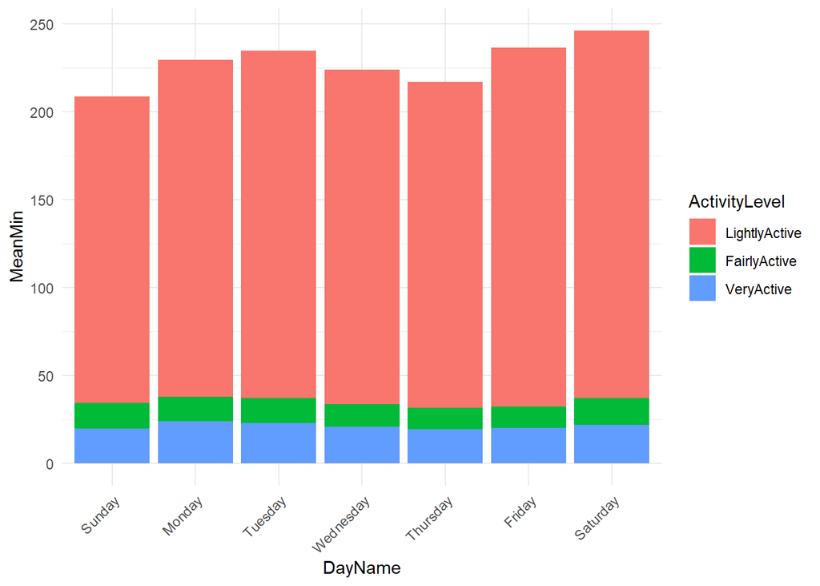

- Users are the most active on Friday and Saturday and the least active Sunday and Thursday.

## Activity Exertion in Minutes

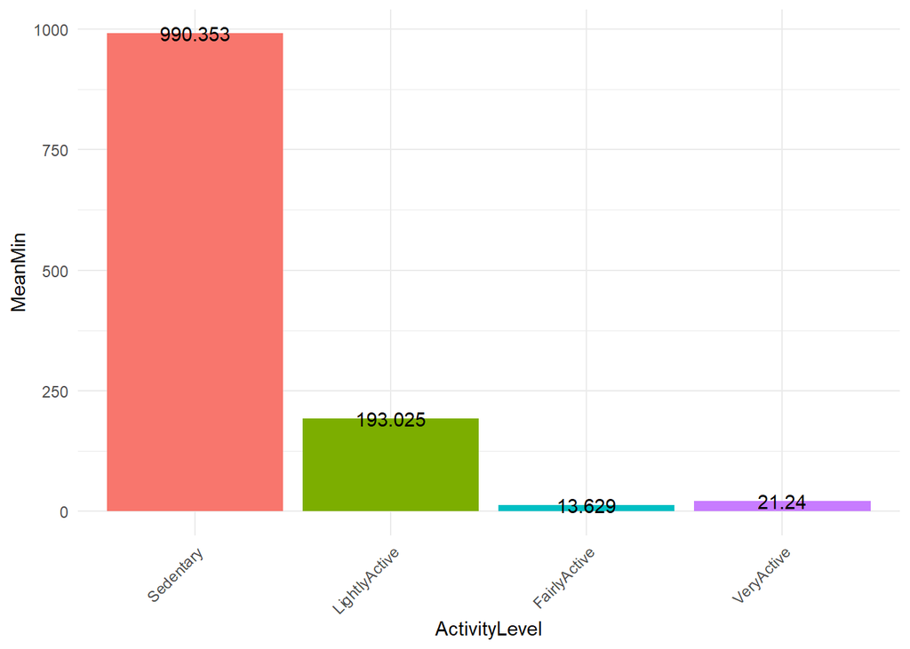

- Individuals exercise for 35 minutes doing higher intensity activity

### Time Series: Minutes Active

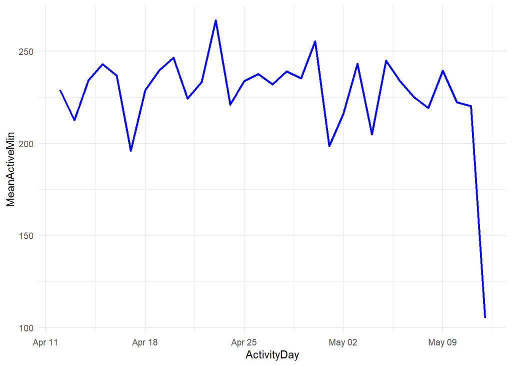

### Time Series: Activity Exertion in Minutes

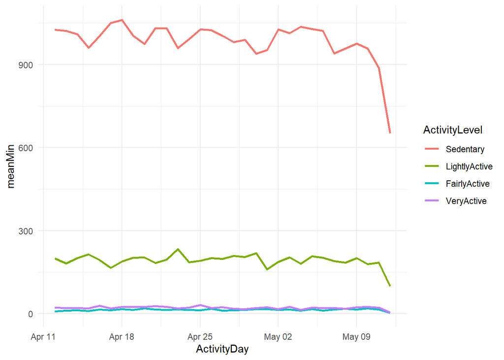

## Activity Exertion in Distance

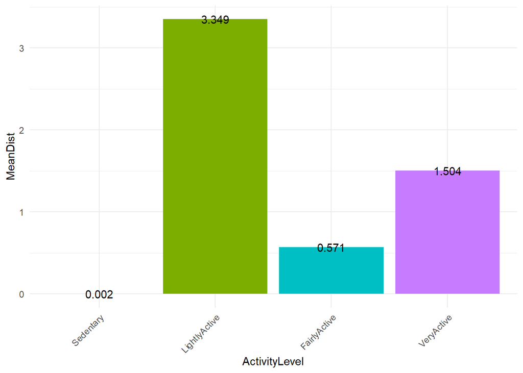

- Individuals travel 2 miles during higher intensity activity

### Time Series: Distance Active

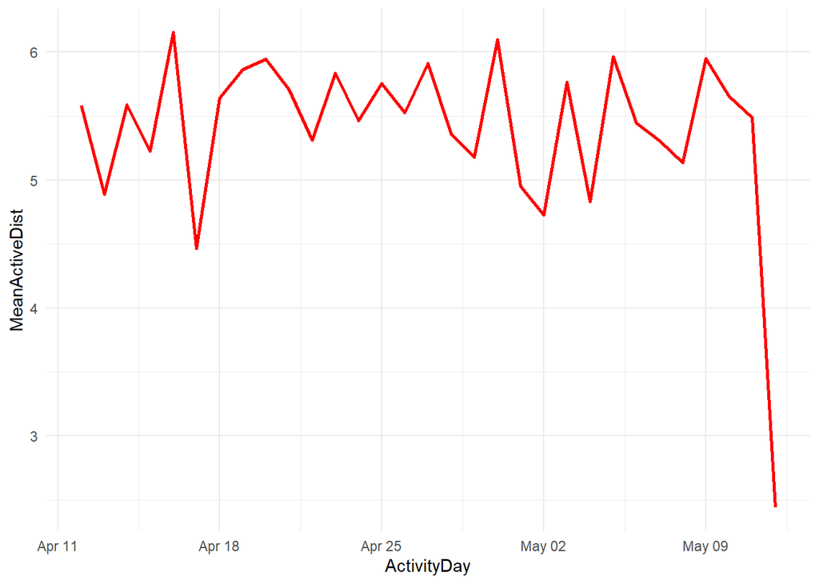

### Time Series: Activity Exertion in Distance

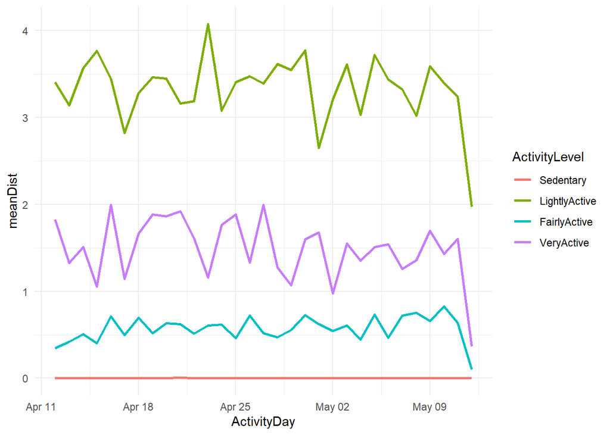

## Average Hours Slept

| AvgHoursAsleep |
| --- |
| 6.991671 |

- The average user sleeps only 7 hours each night.

### Sleep throughout the Week

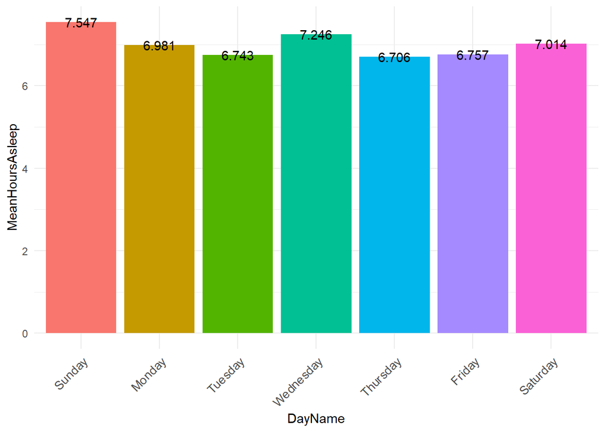

- Individuals sleep best on Sundays.

## Average Calories Consumed

| Calories |
| --- |
| 2307.508 |

- Individuals consume 300 calories above the recommended 2000 calories for woman.

### Average Calories Consumed over the Week

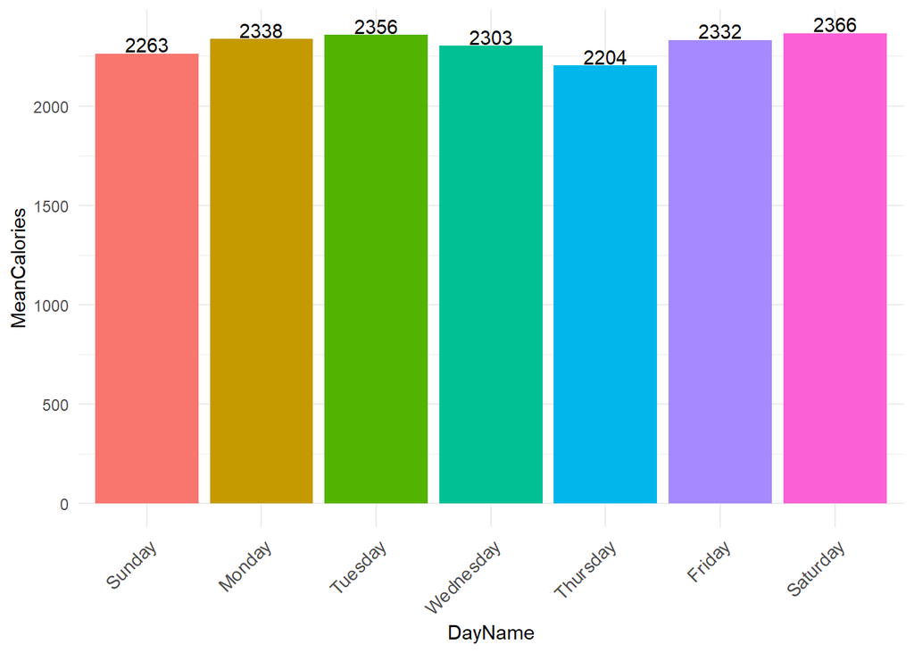

- Users eat the least on Sundays and Thursdays.

## Matrices: Comparing Fields

Next we create Matrices to see if there are any interesting relationships between fields/predictors/columns.

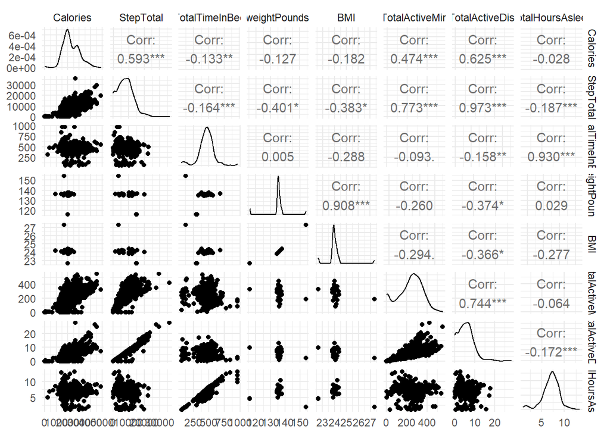

- Unsurprisingly, Calories Burned, Step Total, Total Minutes Active, and Active Distance Traveled all have a strong positive correlation.
  - They are all negatively correlated with BMI.
- Their is a strong positive correlation between Time Spent in Bed and Hours Slept.
- The correlation between weight measures such as weight and BMI have little to no correlation with Total Hours Slept.
- Total Step Total and Total active distance traveled have a negative correlation with Total hours slept.

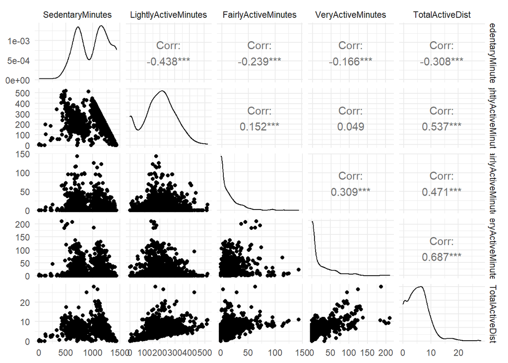

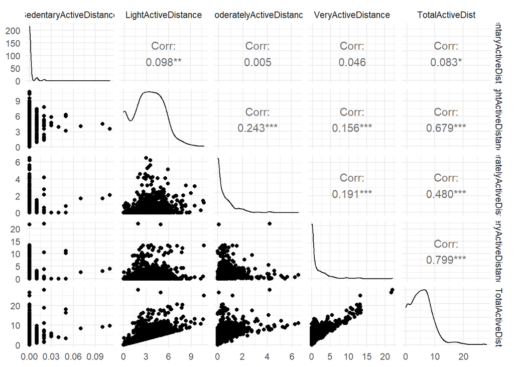

# Acting on our Findings

**Users are Not Sleeping Enough**

We must get members to increase their average sleep duration. This can be done by incentivising users to get in their bed earlier. For example, we can implement a deep breathing feature in app that can help users get ready for bed.

**Need better ways to Record Weight /BMI**

It is difficult to analyze weight and BMI accurately if our data is incomplete. Developing a new scale product can help remedy this. This product can connect to the Bellabeat app and auto record other statistics. For example, Bone Density, Fat, Water and Muscle percentages can be potential measures.

**Meal-Kit Initiative**

Users are consistently eating the above recommended number of calories. A possible solution is to launch a new service that provides measured calorie meals, to take out the guess work from counting calories. Partnering with an already existing company can also work in mitigating calorie intake.